# Fit_Test_Proportion_Studies

Lan Tao

2023-12-05

## update data

```r
## helper function
visual <- function(dataset, alpha, beta){
  x <- seq(0,1,by=0.001)
  fitted_val <- dbeta(x, shape1=alpha, shape2=beta)
  fitted_data <- data.frame(x, fitted_val)
  g <- ggplot(dataset, aes(x=prop_s)) +
    geom_histogram(aes(y=..density..), colour="black", fill="white")+
    geom_density(alpha=.2, colour="palevioletred1",fill="palevioletred1")+
    geom_point(data = fitted_data, aes(x = x, y = fitted_val), colour = "cornflowerblue", size=0.1, show.legend = TRUE)+
    # labs(title = "Patient - m=100, p1=0.03, p2=0.01")+
    theme_bw()
  return(g)
}

# g <- visual(num_patient_05_m100_pr2_11[501:1000, ], alpha_star, beta_star)
# g + labs(title = "Patient - m=100, p1=0.03, p2=0.01")
```

## Hypothesis test

$$H_0: \text{ Beta CDF (s) is following unif(0,1)} \\
H_0: \text{ Beta CDF (s) is not following unif(0,1)}$$

## Data from Patient algorithm

### Patient - group 11 (m=70, pa=0.5, p1=0.03, p2=0.01, pr=2)

```r
# Patient m=70, pa=0.5, p1=0.03, p2=0.01, pr=2
dataset <- num_patient_05_m70_pr2_11[501:1000,]
data <- dataset$prop_s
n <- length(data)
eff_n <- sum(!is.na(data)) # the number of non-na elements
print(paste("The number of non-na elements is",eff_n))
```

```
## [1] "The number of non-na elements is 500"
```

```r
par <- ebeta(data, method = "mle") # the warning may come from the fact that several values = 1
# ebeta(data[500:1000], method = "mme")
alpha_star <- as.numeric(par$parameters[1])
beta_star <- as.numeric(par$parameters[2])
print(paste("The mle estimator for alpha = ", alpha_star, "beta =", beta_star))
```

```
## [1] "The mle estimator for alpha =  9.39596487866648 beta = 1.81499376942783"
```

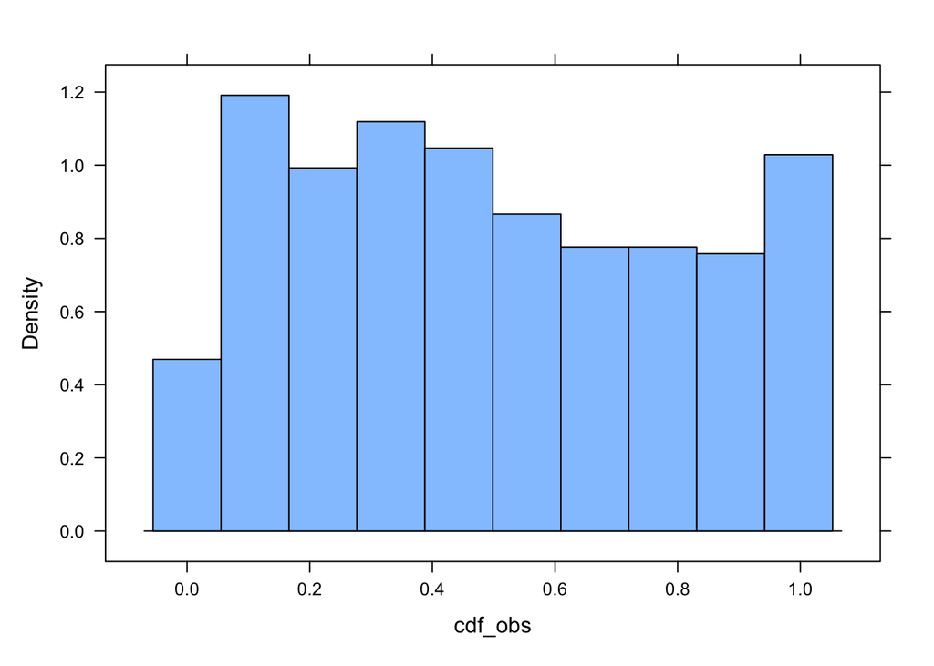

```r
# histogram(alpha_emp)
# histogram(beta_emp)
# mean(alpha_emp)
# alpha_star
# mean(beta_emp)
# beta_star

cdf_obs <- numeric(n)
for (i in 1:n){
  s <- data[i]
  cdf_obs[i] <- (pbeta(s, shape1 = alpha_star, shape2 = beta_star))
}

histogram(cdf_obs)
```

```r
ddst.uniform.test(cdf_obs, compute.p = TRUE)
```

```
##
##  Data Driven Smooth Test for Uniformity
##
## data:  cdf_obs,   base: ddst.base.legendre   c: 2.4
## WT = 53.046, n. coord = 10, p-value < 2.2e-16
```

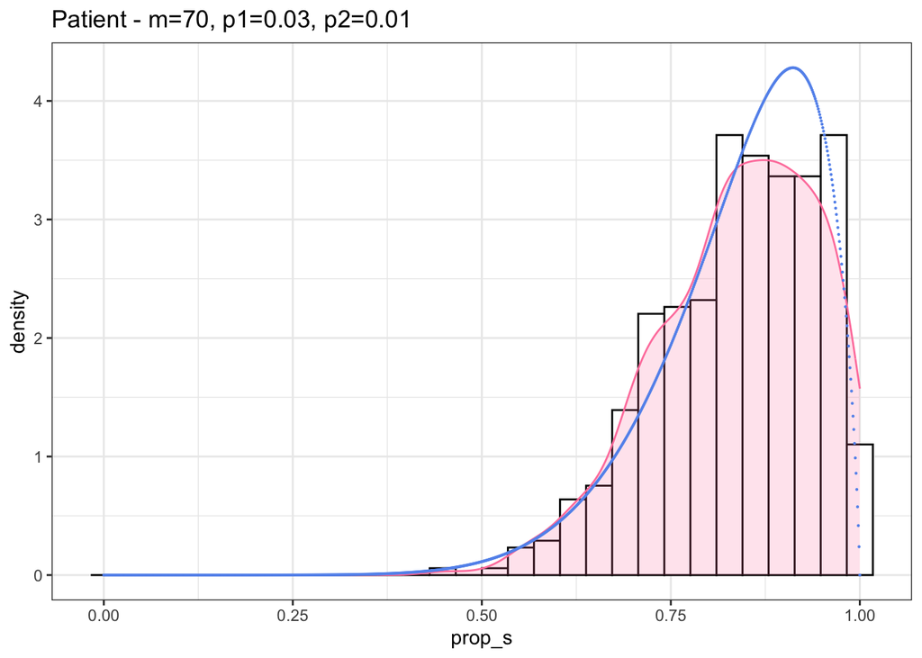

```r
g <- visual(dataset, alpha_star, beta_star)
g + labs(title = "Patient - m=70, p1=0.03, p2=0.01")
```

### Patient - group 12 (m=70, pa=0.5, p1=0.05, p2=0.01, pr=2)

```r
# Patient m=70, pa=0.5, p1=0.05, p2=0.01, pr=2
dataset <- num_patient_05_m70_pr2_12[501:1000,]
data <- dataset$prop_s
n <- length(data)
eff_n <- sum(!is.na(data)) # the number of non-na elements
print(paste("The number of non-na elements is",eff_n))
```

```
## [1] "The number of non-na elements is 500"
```

```r
par <- ebeta(data, method = "mle") # the warning may come from the fact that several values = 1
# ebeta(data[500:1000], method = "mme")
alpha_star <- as.numeric(par$parameters[1])
beta_star <- as.numeric(par$parameters[2])
print(paste("The mle estimator for alpha = ", alpha_star, "beta =", beta_star))
```

```
## [1] "The mle estimator for alpha =  7.10371711281532 beta = 1.51070173481298"
```

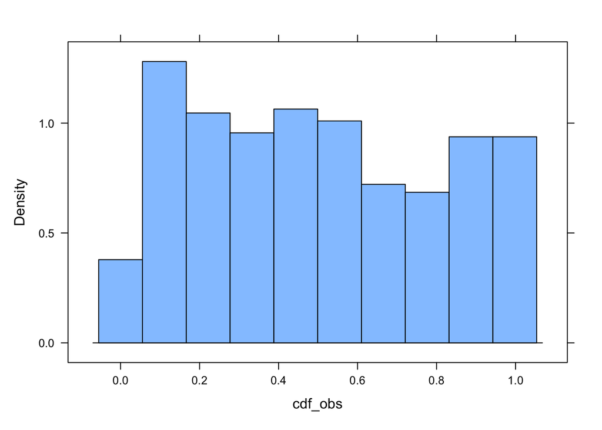

```r
# histogram(alpha_emp)
# histogram(beta_emp)
# mean(alpha_emp)
# alpha_star
# mean(beta_emp)
# beta_star

cdf_obs <- numeric(n)
for (i in 1:n){
  s <- data[i]
  cdf_obs[i] <- (pbeta(s, shape1 = alpha_star, shape2 = beta_star))
}

histogram(cdf_obs)
```

```r
ddst.uniform.test(cdf_obs, compute.p = TRUE)
```

```
##
##  Data Driven Smooth Test for Uniformity
##
## data:  cdf_obs,   base: ddst.base.legendre   c: 2.4
## WT = 97.212, n. coord = 10, p-value < 2.2e-16
```

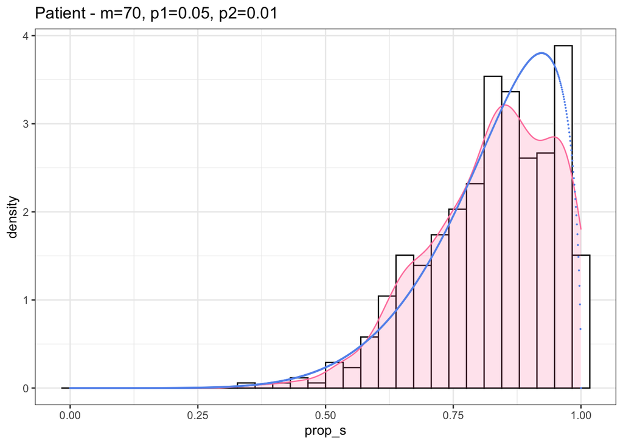

```r
g <- visual(dataset, alpha_star, beta_star)
g + labs(title = "Patient - m=70, p1=0.05, p2=0.01")
```

### Patient - group 13 (m=70, pa=0.5, p1=0.1, p2=0.01, pr=2)

```r
# Patient m=70, pa=0.5, p1=0.1, p2=0.01, pr=2
dataset <- num_patient_05_m70_pr2_13[501:1000,]
data <- dataset$prop_s
n <- length(data)
eff_n <- sum(!is.na(data)) # the number of non-na elements
print(paste("The number of non-na elements is",eff_n))
```

```
## [1] "The number of non-na elements is 500"
```

```r
par <- ebeta(data, method = "mle") # the warning may come from the fact that several values = 1
# ebeta(data[500:1000], method = "mme")
alpha_star <- as.numeric(par$parameters[1])
beta_star <- as.numeric(par$parameters[2])
print(paste("The mle estimator for alpha = ", alpha_star, "beta =", beta_star))
```

```
## [1] "The mle estimator for alpha =  6.33212225876424 beta = 1.52990567051852"
```

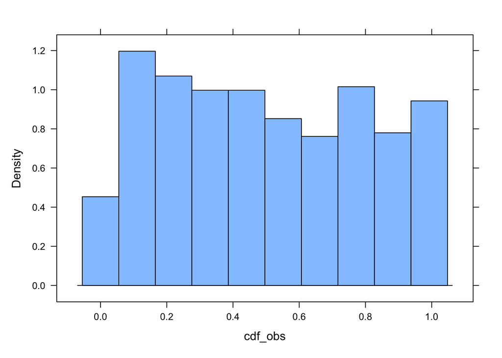

```r
# histogram(alpha_emp)
# histogram(beta_emp)
# mean(alpha_emp)
# alpha_star
# mean(beta_emp)
# beta_star

cdf_obs <- numeric(n)
for (i in 1:n){
  s <- data[i]
  cdf_obs[i] <- (pbeta(s, shape1 = alpha_star, shape2 = beta_star))
}

histogram(cdf_obs)
```

```r
ddst.uniform.test(cdf_obs, compute.p = TRUE)
```

```
##
##  Data Driven Smooth Test for Uniformity
##
## data:  cdf_obs,   base: ddst.base.legendre   c: 2.4
## WT = 0.016504, n. coord = 1, p-value = 0.909
```

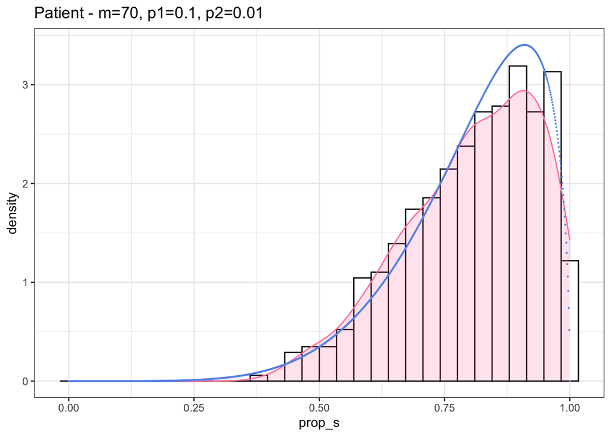

```r
g <- visual(dataset, alpha_star, beta_star)
g + labs(title = "Patient - m=70, p1=0.1, p2=0.01")
```

### Patient - group 14 (m=70, pa=0.5, p1=0.8, p2=0.01, pr=2)

```r
# Patient m=70, pa=0.5, p1=0.8, p2=0.01, pr=2
dataset <- num_patient_05_m70_pr2_14[501:1000,]
data <- dataset$prop_s
n <- length(data)
eff_n <- sum(!is.na(data)) # the number of non-na elements
print(paste("The number of non-na elements is",eff_n))
```

```
## [1] "The number of non-na elements is 500"
```

```r
par <- ebeta(data, method = "mle") # the warning may come from the fact that several values = 1
# ebeta(data[500:1000], method = "mme")
alpha_star <- as.numeric(par$parameters[1])
beta_star <- as.numeric(par$parameters[2])
print(paste("The mle estimator for alpha = ", alpha_star, "beta =", beta_star))
```

```
## [1] "The mle estimator for alpha =  5.8721506909024 beta = 1.46987687000098"
```

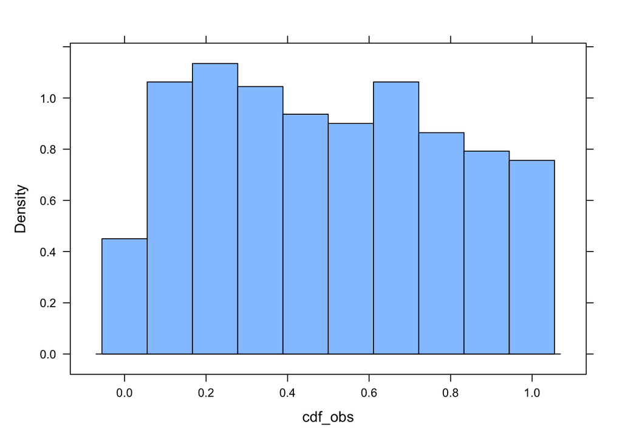

```r
# histogram(alpha_emp)
# histogram(beta_emp)
# mean(alpha_emp)
# alpha_star
# mean(beta_emp)
# beta_star

cdf_obs <- numeric(n)
for (i in 1:n){
  s <- data[i]
  cdf_obs[i] <- (pbeta(s, shape1 = alpha_star, shape2 = beta_star))
}

histogram(cdf_obs)
```

```r
ddst.uniform.test(cdf_obs, compute.p = TRUE)
```

```
##
##  Data Driven Smooth Test for Uniformity
##
## data:  cdf_obs,   base: ddst.base.legendre   c: 2.4
## WT = 0.029255, n. coord = 1, p-value = 0.873
```

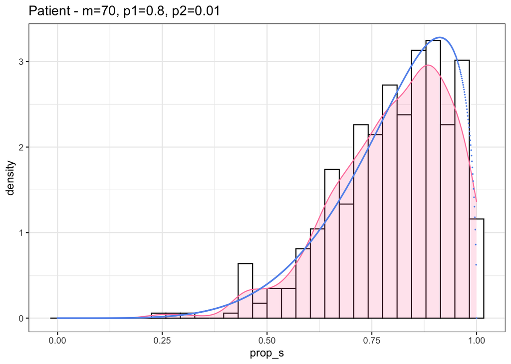

```r
g <- visual(dataset, alpha_star, beta_star)
g + labs(title = "Patient - m=70, p1=0.8, p2=0.01")
```

### Patient - group 21 (m=100, pa=0.5, p1=0.03, p2=0.01, pr=2)

```r
# Patient m=100, pa=0.5, p1=0.03, p2=0.01, pr=2
dataset <- num_patient_05_m100_pr2_11[501:1000,]
data <- dataset$prop_s
n <- length(data)
eff_n <- sum(!is.na(data)) # the number of non-na elements
print(paste("The number of non-na elements is",eff_n))
```

```
## [1] "The number of non-na elements is 500"
```

```r
par <- ebeta(data, method = "mle") # the warning may come from the fact that several values = 1
# ebeta(data[500:1000], method = "mme")
alpha_star <- as.numeric(par$parameters[1])
beta_star <- as.numeric(par$parameters[2])
print(paste("The mle estimator for alpha = ", alpha_star, "beta =", beta_star))
```

```
## [1] "The mle estimator for alpha =  10.5847577595078 beta = 1.81853272358369"
```

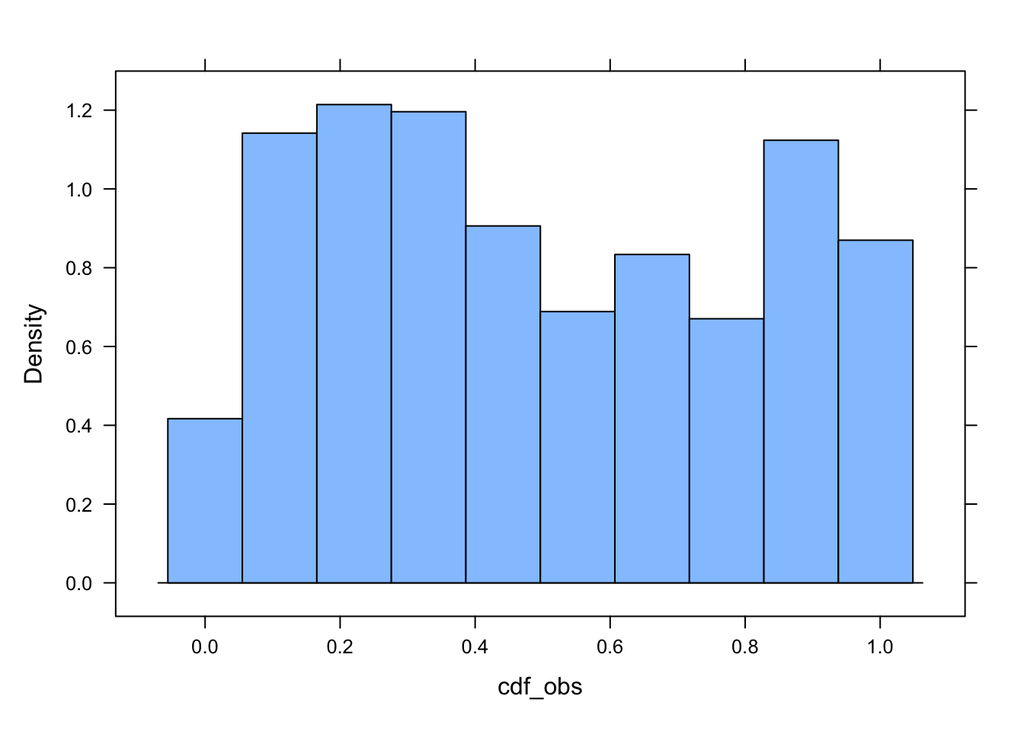

```r
# histogram(alpha_emp)
# histogram(beta_emp)
# mean(alpha_emp)
# alpha_star
# mean(beta_emp)
# beta_star

cdf_obs <- numeric(n)
for (i in 1:n){
  s <- data[i]
  cdf_obs[i] <- (pbeta(s, shape1 = alpha_star, shape2 = beta_star))
}

histogram(cdf_obs)
```

```r
ddst.uniform.test(cdf_obs, compute.p = TRUE)
```

```
##
##  Data Driven Smooth Test for Uniformity
##
## data:  cdf_obs,   base: ddst.base.legendre   c: 2.4
## WT = 78.076, n. coord = 10, p-value < 2.2e-16
```

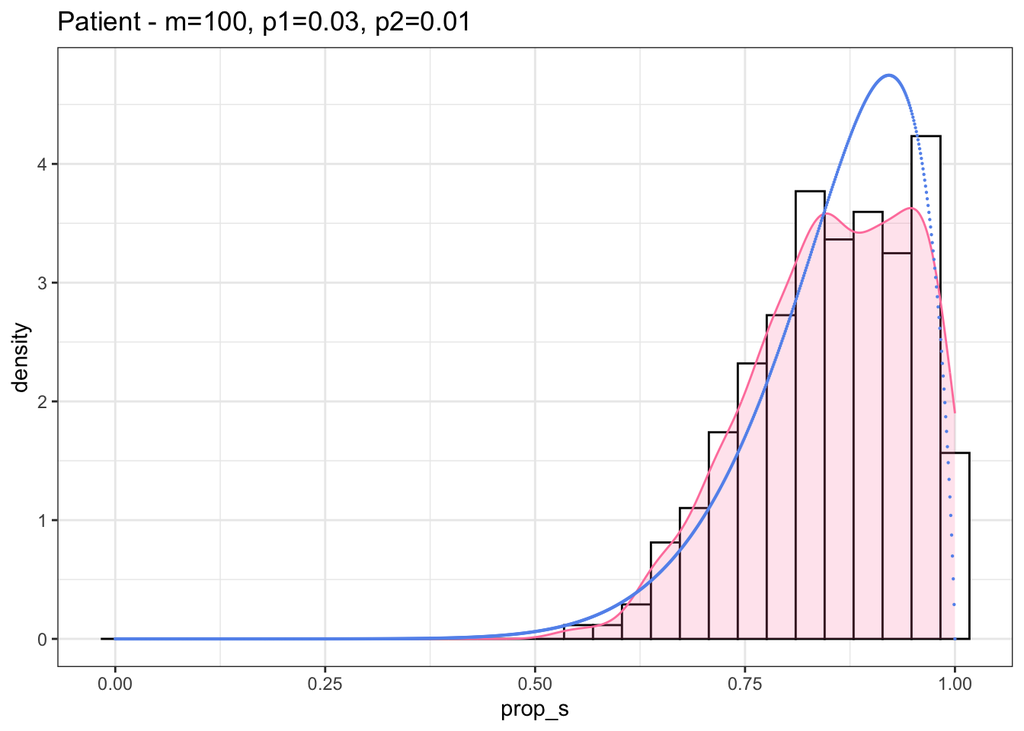

```r
g <- visual(dataset, alpha_star, beta_star)
g + labs(title = "Patient - m=100, p1=0.03, p2=0.01")
```

### Patient - group 22 (m=100, pa=0.5, p1=0.05, p2=0.01, pr=2)

```r
# Patient m=100, pa=0.5, p1=0.05, p2=0.01, pr=2
dataset <- num_patient_05_m100_pr2_12[501:1000,]
data <- dataset$prop_s
n <- length(data)
eff_n <- sum(!is.na(data)) # the number of non-na elements
print(paste("The number of non-na elements is",eff_n))
```

```
## [1] "The number of non-na elements is 500"
```

```r
par <- ebeta(data, method = "mle") # the warning may come from the fact that several values = 1
# ebeta(data[500:1000], method = "mme")
alpha_star <- as.numeric(par$parameters[1])
beta_star <- as.numeric(par$parameters[2])
print(paste("The mle estimator for alpha = ", alpha_star, "beta =", beta_star))
```

```
## [1] "The mle estimator for alpha =  8.94178090625603 beta = 1.70101341393118"
```

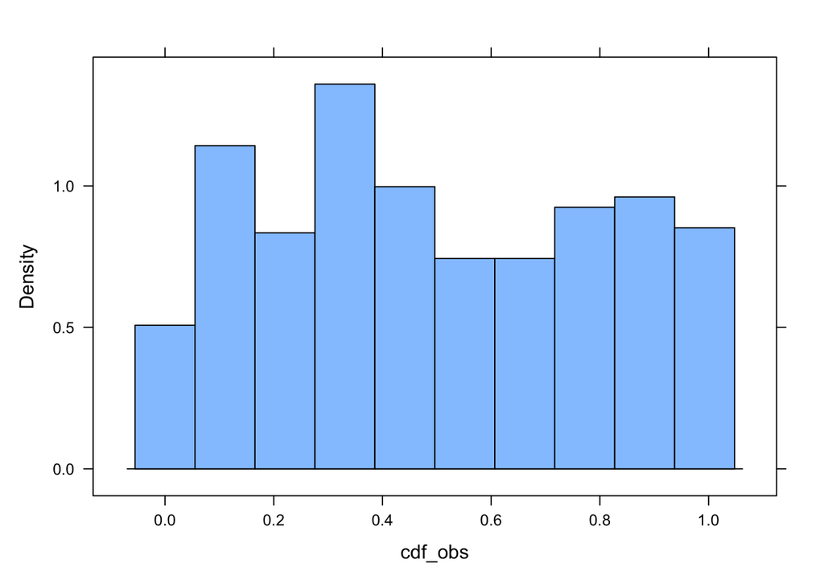

```r
# histogram(alpha_emp)
# histogram(beta_emp)
# mean(alpha_emp)
# alpha_star
# mean(beta_emp)
# beta_star

cdf_obs <- numeric(n)
# chi_obs <- numeric(n)
for (i in 1:n){
  s <- data[i]
  cdf_obs[i] <- (pbeta(s, shape1 = alpha_star, shape2 = beta_star))
  # chi_obs[i] <- -2*log(cdf_obs[i])
}

histogram(cdf_obs)
```

```r
# histogram(chi_obs)
ddst.uniform.test(cdf_obs, compute.p = TRUE)
```

```
##
##  Data Driven Smooth Test for Uniformity
##
## data:  cdf_obs,   base: ddst.base.legendre   c: 2.4
## WT = 83.908, n. coord = 10, p-value < 2.2e-16
```

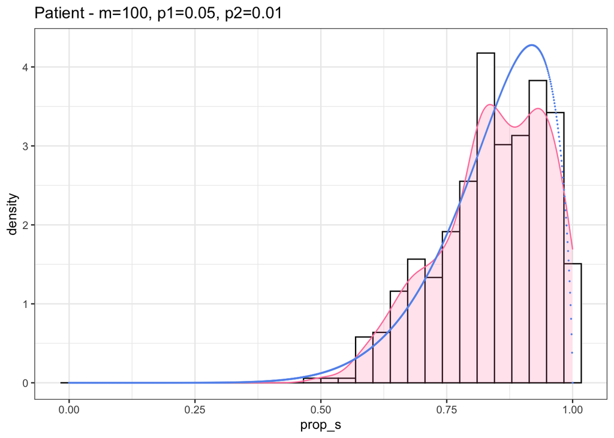

```r
g <- visual(dataset, alpha_star, beta_star)
g + labs(title = "Patient - m=100, p1=0.05, p2=0.01")
```

### Patient - group 23 (m=100, pa=0.5, p1=0.1, p2=0.01, pr=2)

```r
# Patient m=100, pa=0.5, p1=0.1, p2=0.01, pr=2
dataset <- num_patient_05_m100_pr2_13[501:1000,]
data <- dataset$prop_s
n <- length(data)
eff_n <- sum(!is.na(data)) # the number of non-na elements
print(paste("The number of non-na elements is",eff_n))
```

```
## [1] "The number of non-na elements is 500"
```

```r
par <- ebeta(data, method = "mle") # the warning may come from the fact that several values = 1
# ebeta(data[500:1000], method = "mme")
alpha_star <- as.numeric(par$parameters[1])
beta_star <- as.numeric(par$parameters[2])
print(paste("The mle estimator for alpha = ", alpha_star, "beta =", beta_star))
```

```
## [1] "The mle estimator for alpha =  7.68974552431353 beta = 1.49837307508402"
```

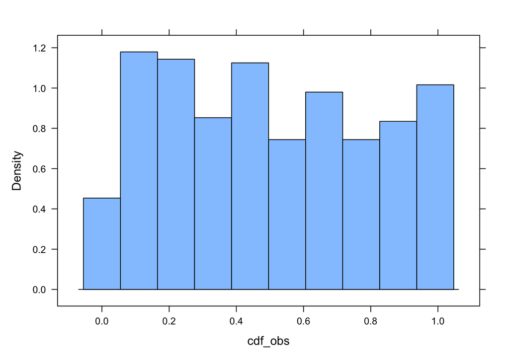

```r
# histogram(alpha_emp)
# histogram(beta_emp)
# mean(alpha_emp)
# alpha_star
# mean(beta_emp)
# beta_star

cdf_obs <- numeric(n)
for (i in 1:n){
  s <- data[i]
  cdf_obs[i] <- (pbeta(s, shape1 = alpha_star, shape2 = beta_star))
}

histogram(cdf_obs)
```

```r
ddst.uniform.test(cdf_obs, compute.p = TRUE)
```

```
##
##  Data Driven Smooth Test for Uniformity
##
## data:  cdf_obs,   base: ddst.base.legendre   c: 2.4
## WT = 16.163, n. coord = 3, p-value = 0.001
```

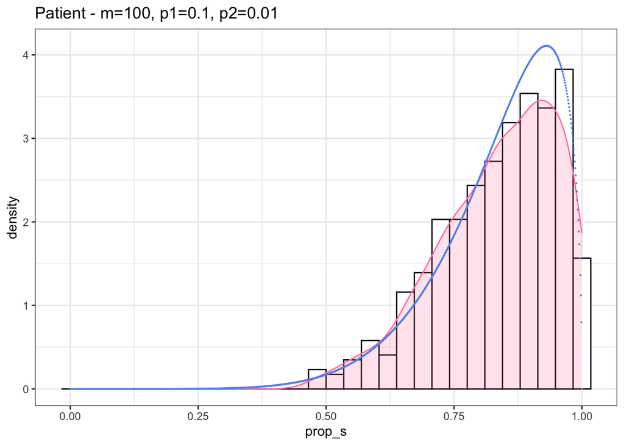

```r
g <- visual(dataset, alpha_star, beta_star)
g + labs(title = "Patient - m=100, p1=0.1, p2=0.01")
```

### Patient - group 24 (m=100, pa=0.5, p1=0.8, p2=0.01, pr=2)

```r
# Patient m=100, pa=0.5, p1=0.8, p2=0.01, pr=2
dataset <- num_patient_05_m100_pr2_14[501:1000,]
data <- dataset$prop_s
n <- length(data)
eff_n <- sum(!is.na(data)) # the number of non-na elements
print(paste("The number of non-na elements is",eff_n))
```

```
## [1] "The number of non-na elements is 500"
```

```r
par <- ebeta(data, method = "mle") # the warning may come from the fact that several values = 1
# ebeta(data[500:1000], method = "mme")
alpha_star <- as.numeric(par$parameters[1])
beta_star <- as.numeric(par$parameters[2])
print(paste("The mle estimator for alpha = ", alpha_star, "beta =", beta_star))
```

```
## [1] "The mle estimator for alpha =  7.43563260997576 beta = 1.56098512226581"
```

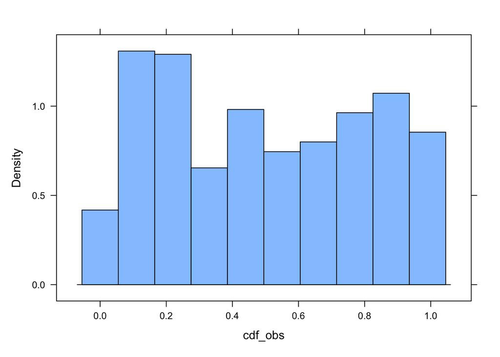

```r
# histogram(alpha_emp)
# histogram(beta_emp)
# mean(alpha_emp)
# alpha_star
# mean(beta_emp)
# beta_star

cdf_obs <- numeric(n)
for (i in 1:n){
  s <- data[i]
  cdf_obs[i] <- (pbeta(s, shape1 = alpha_star, shape2 = beta_star))
}

histogram(cdf_obs)
```

```r
ddst.uniform.test(cdf_obs, compute.p = TRUE)
```

```
##
##  Data Driven Smooth Test for Uniformity
##
## data:  cdf_obs,   base: ddst.base.legendre   c: 2.4
## WT = 22.176, n. coord = 3, p-value = 0.001
```

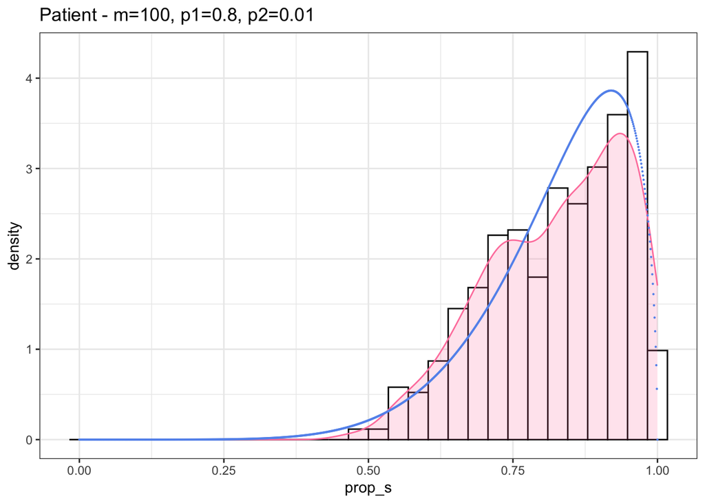

```r
g <- visual(dataset, alpha_star, beta_star)
g + labs(title = "Patient - m=100, p1=0.8, p2=0.01")
```

## Data from Greedy algorithm

### Remark: We guess the goodness of fit test would not be good from the visual inspection

### Greedy - group 11 (m=70, pa=0.5, p1=0.03, p2=0.01, pr=2)

```r
# Greedy m=70, pa=0.5, p1=0.03, p2=0.01, pr=2
dataset <- num_greedy_05_m70_pr2_11[501:1000,]
data <- dataset$prop_s
n <- length(data)
eff_n <- sum(!is.na(data)) # the number of non-na elements
print(paste("The number of non-na elements is",eff_n))
```

```
## [1] "The number of non-na elements is 500"
```

```r
par <- ebeta(data, method = "mle") # the warning may come from the fact that several values = 1
# ebeta(data[500:1000], method = "mme")
alpha_star <- as.numeric(par$parameters[1])
beta_star <- as.numeric(par$parameters[2])
print(paste("The mle estimator for alpha = ", alpha_star, "beta =", beta_star))
```

```
## [1] "The mle estimator for alpha =  5.03239083230149 beta = 1.39890647854762"
```

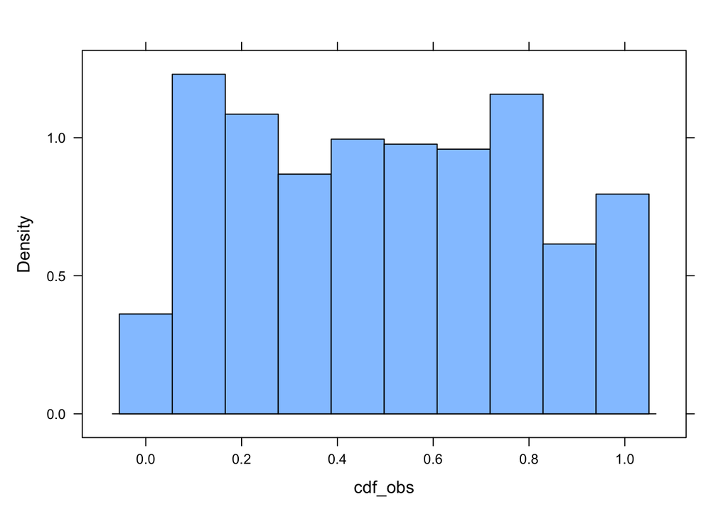

```r
# histogram(alpha_emp)
# histogram(beta_emp)
# mean(alpha_emp)
# alpha_star
# mean(beta_emp)
# beta_star

cdf_obs <- numeric(n)
for (i in 1:n){
  s <- data[i]
  cdf_obs[i] <- (pbeta(s, shape1 = alpha_star, shape2 = beta_star))
}

histogram(cdf_obs)
```

```r
ddst.uniform.test(cdf_obs, compute.p = TRUE)
```

```
##
##  Data Driven Smooth Test for Uniformity
##
## data:  cdf_obs,   base: ddst.base.legendre   c: 2.4
## WT = 504.07, n. coord = 10, p-value < 2.2e-16
```

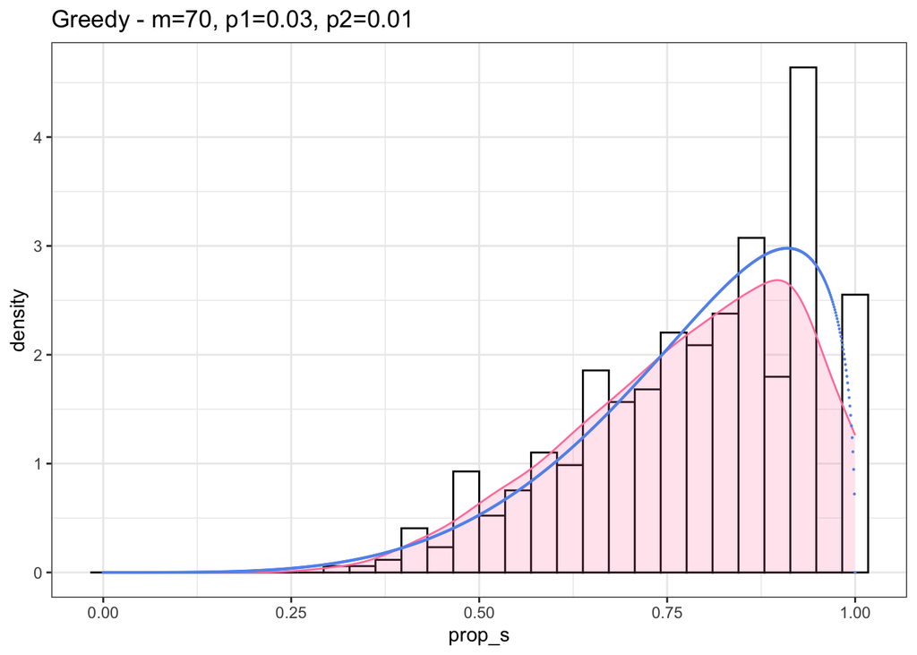

```r
g <- visual(dataset, alpha_star, beta_star)
g + labs(title = "Greedy - m=70, p1=0.03, p2=0.01")
```

### Greedy - group 12 (m=70, pa=0.5, p1=0.05, p2=0.01, pr=2)

```r
# Greedy m=70, pa=0.5, p1=0.05, p2=0.01, pr=2
dataset <- num_greedy_05_m70_pr2_12[501:1000,]
data <- dataset$prop_s
n <- length(data)
eff_n <- sum(!is.na(data)) # the number of non-na elements
print(paste("The number of non-na elements is",eff_n))
```

```
## [1] "The number of non-na elements is 500"
```

```r
par <- ebeta(data, method = "mle") # the warning may come from the fact that several values = 1
# ebeta(data[500:1000], method = "mme")
alpha_star <- as.numeric(par$parameters[1])
beta_star <- as.numeric(par$parameters[2])
print(paste("The mle estimator for alpha = ", alpha_star, "beta =", beta_star))
```

```
## [1] "The mle estimator for alpha =  3.82399335503446 beta = 1.33229370053675"
```

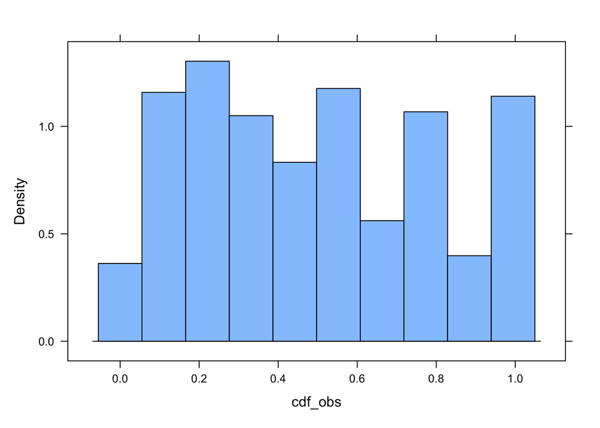

```r
# histogram(alpha_emp)
# histogram(beta_emp)
# mean(alpha_emp)
# alpha_star
# mean(beta_emp)
# beta_star

cdf_obs <- numeric(n)
for (i in 1:n){
  s <- data[i]
  cdf_obs[i] <- (pbeta(s, shape1 = alpha_star, shape2 = beta_star))
}

histogram(cdf_obs)
```

```r
ddst.uniform.test(cdf_obs, compute.p = TRUE)
```

```
##
##  Data Driven Smooth Test for Uniformity
##
## data:  cdf_obs,   base: ddst.base.legendre   c: 2.4
## WT = 925.43, n. coord = 10, p-value < 2.2e-16
```

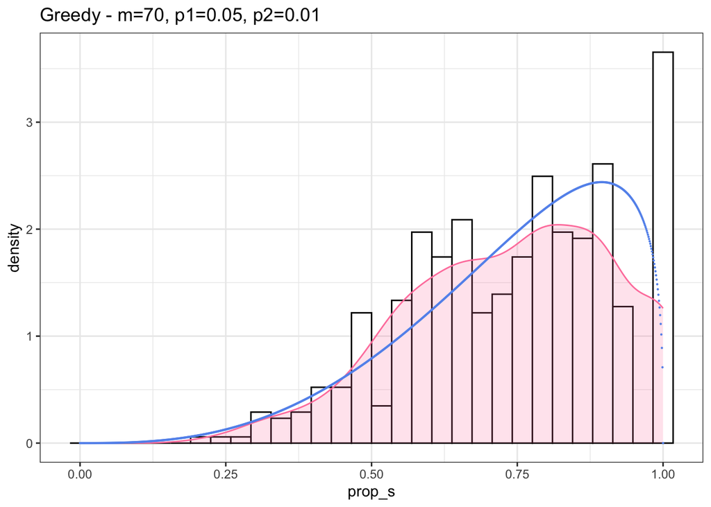

```r
g <- visual(dataset, alpha_star, beta_star)
g + labs(title = "Greedy - m=70, p1=0.05, p2=0.01")
```

### Greedy - group 13 (m=70, pa=0.5, p1=0.1, p2=0.01, pr=2)

#### warning: there are inf values in this situation

```r
# Greedy m=70, pa=0.5, p1=0.1, p2=0.01, pr=2
dataset <- num_greedy_05_m70_pr2_13[501:1000,]
data <- dataset$prop_s
n <- length(data)
eff_n <- sum(!is.na(data)) # the number of non-na elements
print(paste("The number of non-na elements is",eff_n))
```

```
## [1] "The number of non-na elements is 500"
```

```r
par <- ebeta(data, method = "mle") # the warning may come from the fact that several values = 1
```

```
## Warning in is.not.finite.warning(x): There were 1 nonfinite values in x : 1
## +-Inf's
```

```r
# ebeta(data[500:1000], method = "mme")
alpha_star <- as.numeric(par$parameters[1])
beta_star <- as.numeric(par$parameters[2])
print(paste("The mle estimator for alpha = ", alpha_star, "beta =", beta_star))
```

```
## [1] "The mle estimator for alpha =  2.25435936644977 beta = 1.07261191720756"
```

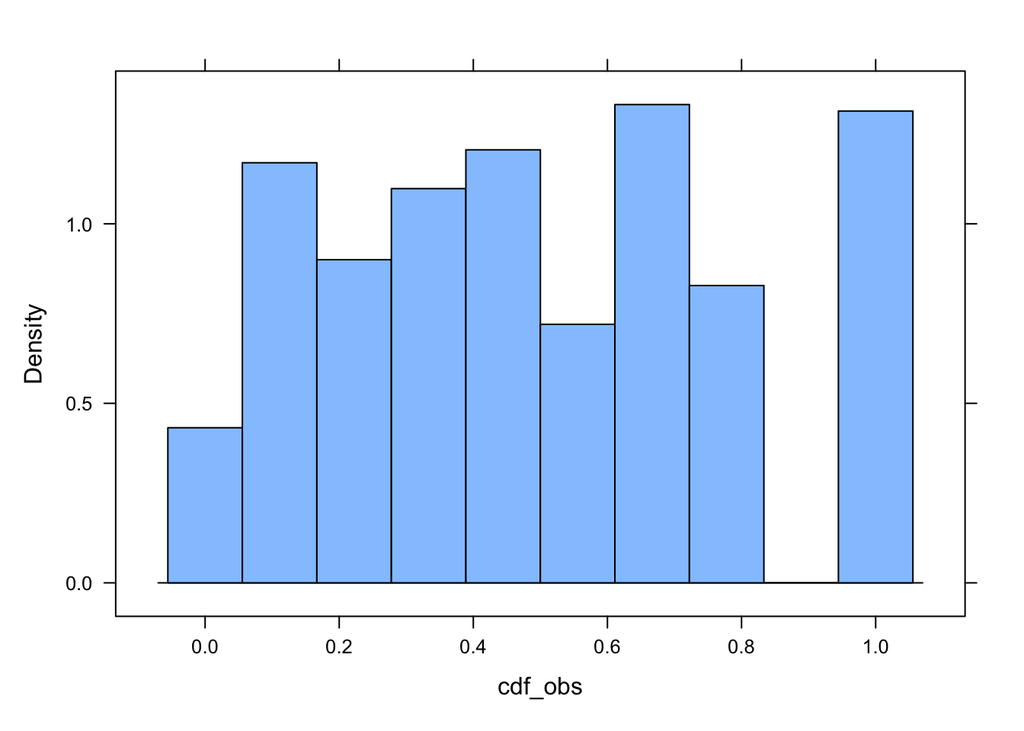

```r
# histogram(alpha_emp)
# histogram(beta_emp)
# mean(alpha_emp)
# alpha_star
# mean(beta_emp)
# beta_star

cdf_obs <- numeric(n)
for (i in 1:n){
  s <- data[i]
  cdf_obs[i] <- (pbeta(s, shape1 = alpha_star, shape2 = beta_star))
}

histogram(cdf_obs)
```

```r
ddst.uniform.test(cdf_obs, compute.p = TRUE)
```

```
##
##  Data Driven Smooth Test for Uniformity
##
## data:  cdf_obs,   base: ddst.base.legendre   c: 2.4
## WT = 1193.4, n. coord = 10, p-value < 2.2e-16
```

```r
g <- visual(dataset, alpha_star, beta_star)
g + labs(title = "Greedy - m=70, p1=0.1, p2=0.01")
```

```
## Warning: Removed 1 rows containing non-finite values (`stat_bin()`).
```

```
## Warning: Removed 1 rows containing non-finite values (`stat_density()`).
```

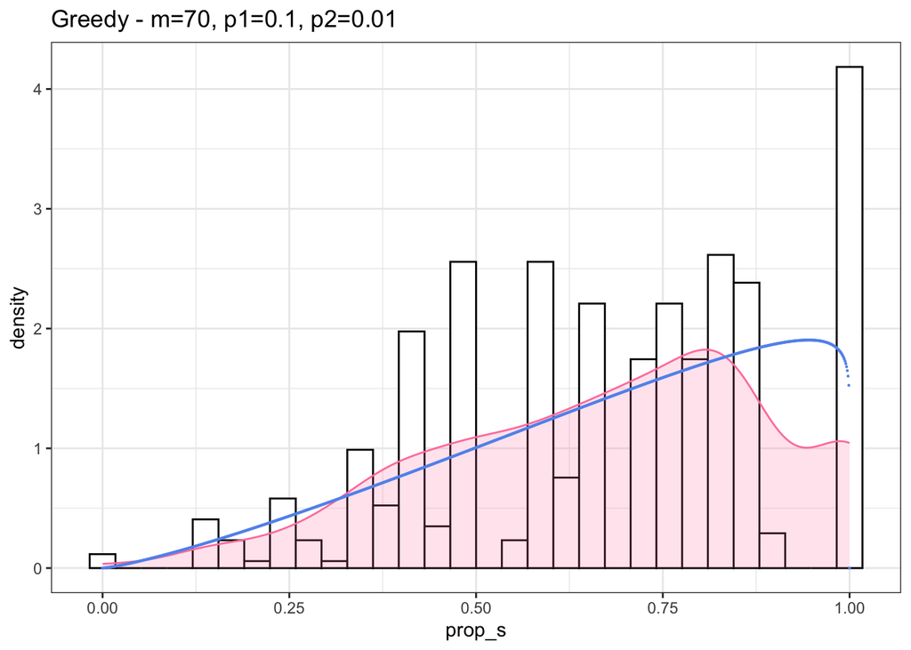

### Greedy - group 14 (m=70, pa=0.5, p1=0.8, p2=0.01, pr=2)

#### warning: there are inf values in this situation; apparently the distribution of s concentrated on $\{0, 0.5, 1\}$.

```r
# Greedy m=70, pa=0.5, p1=0.8, p2=0.01, pr=2
dataset <- num_greedy_05_m70_pr2_14[501:1000,]
data <- dataset$prop_s
n <- length(data)
eff_n <- sum(!is.na(data)) # the number of non-na elements
print(paste("The number of non-na elements is",eff_n))
```

```
## [1] "The number of non-na elements is 380"
```

```r
par <- ebeta(data, method = "mle") # the warning may come from the fact that several values = 1
```

```
## Warning in is.not.finite.warning(x): There were 242 nonfinite values in x : 120
## NA's, 122 +-Inf's
```

```r
# ebeta(data[500:1000], method = "mme")
alpha_star <- as.numeric(par$parameters[1])
beta_star <- as.numeric(par$parameters[2])
print(paste("The mle estimator for alpha = ", alpha_star, "beta =", beta_star))
```

```
## [1] "The mle estimator for alpha =  0.0510128995178173 beta = 0.0616375547990319"
```

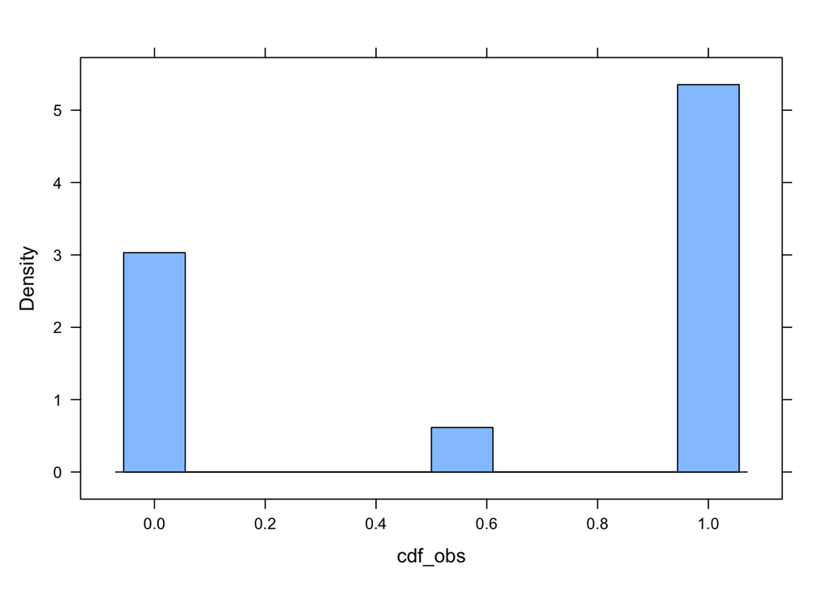

```r
# histogram(alpha_emp)
# histogram(beta_emp)
# mean(alpha_emp)
# alpha_star
# mean(beta_emp)
# beta_star

cdf_obs <- numeric(n)
for (i in 1:n){
  s <- data[i]
  cdf_obs[i] <- (pbeta(s, shape1 = alpha_star, shape2 = beta_star))
}

histogram(cdf_obs)
```

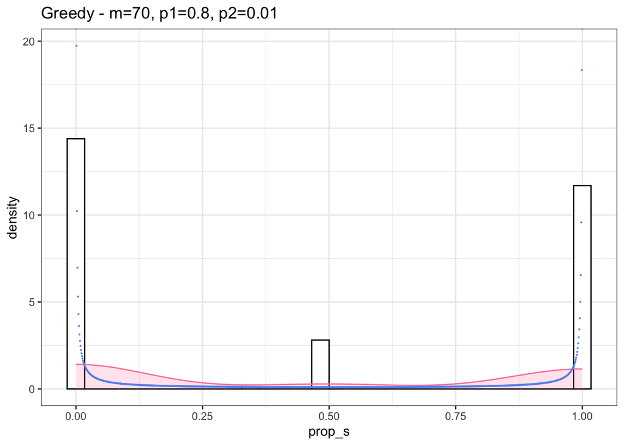

```r
# ddst.uniform.test(cdf_obs, compute.p = TRUE)

g <- visual(dataset, alpha_star, beta_star)
g + labs(title = "Greedy - m=70, p1=0.8, p2=0.01")
```

### Greedy - group 21 (m=100, pa=0.5, p1=0.03, p2=0.01, pr=2)

```r
# Greedy m=100, pa=0.5, p1=0.03, p2=0.01, pr=2
dataset <- num_greedy_05_m100_pr2_11[501:1000,]
data <- dataset$prop_s
n <- length(data)
eff_n <- sum(!is.na(data)) # the number of non-na elements
print(paste("The number of non-na elements is",eff_n))
```

```
## [1] "The number of non-na elements is 500"
```

```r
par <- ebeta(data, method = "mle") # the warning may come from the fact that several values = 1
# ebeta(data[500:1000], method = "mme")
alpha_star <- as.numeric(par$parameters[1])
beta_star <- as.numeric(par$parameters[2])
print(paste("The mle estimator for alpha = ", alpha_star, "beta =", beta_star))
```

```
## [1] "The mle estimator for alpha =  4.85796892348785 beta = 1.54659867915711"
```

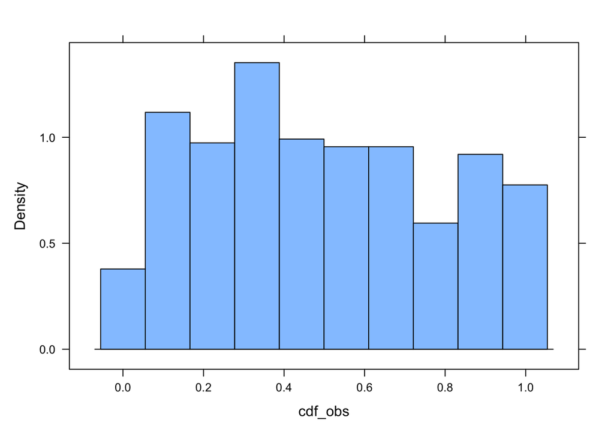

```r
# histogram(alpha_emp)
# histogram(beta_emp)
# mean(alpha_emp)
# alpha_star
# mean(beta_emp)
# beta_star

cdf_obs <- numeric(n)
for (i in 1:n){
  s <- data[i]
  cdf_obs[i] <- (pbeta(s, shape1 = alpha_star, shape2 = beta_star))
}

histogram(cdf_obs)
```

```r
ddst.uniform.test(cdf_obs, compute.p = TRUE)
```

```
##
##  Data Driven Smooth Test for Uniformity
##
## data:  cdf_obs,   base: ddst.base.legendre   c: 2.4
## WT = 444.36, n. coord = 10, p-value < 2.2e-16
```

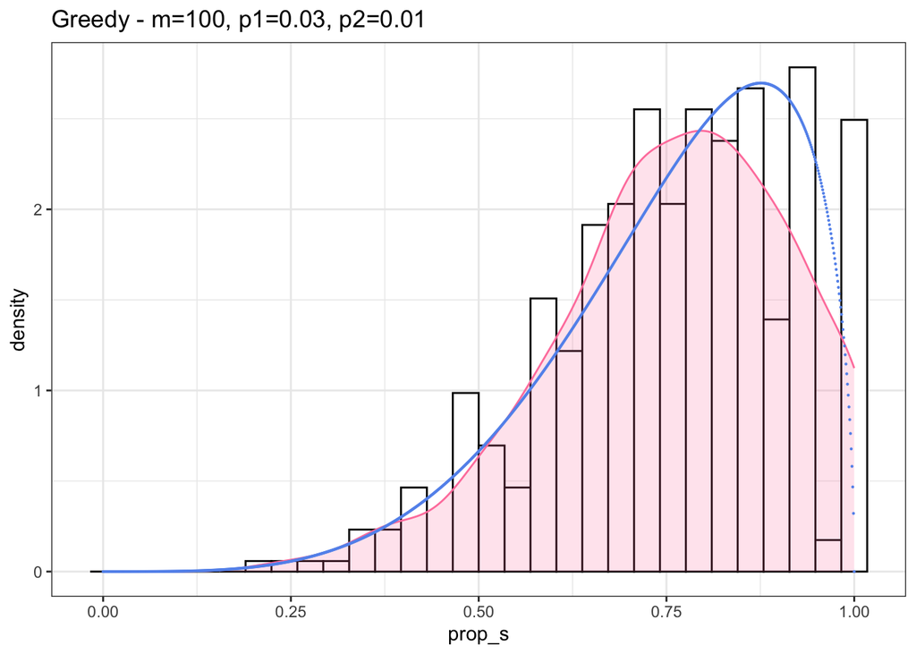

```r
g <- visual(dataset, alpha_star, beta_star)
g + labs(title = "Greedy - m=100, p1=0.03, p2=0.01")
```

### Greedy - group 22 (m=100, pa=0.5, p1=0.05, p2=0.01, pr=2)

```r
# Greedy m=100, pa=0.5, p1=0.05, p2=0.01, pr=2
dataset <- num_greedy_05_m100_pr2_12[501:1000,]
data <- dataset$prop_s
n <- length(data)
eff_n <- sum(!is.na(data)) # the number of non-na elements
print(paste("The number of non-na elements is",eff_n))
```

```
## [1] "The number of non-na elements is 500"
```

```r
par <- ebeta(data, method = "mle") # the warning may come from the fact that several values = 1
# ebeta(data[500:1000], method = "mme")
alpha_star <- as.numeric(par$parameters[1])
beta_star <- as.numeric(par$parameters[2])
print(paste("The mle estimator for alpha = ", alpha_star, "beta =", beta_star))
```

```
## [1] "The mle estimator for alpha =  3.55007139821545 beta = 1.25761728527144"
```

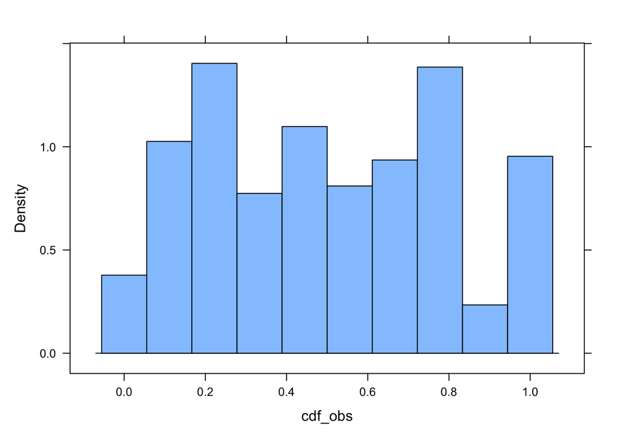

```r
# histogram(alpha_emp)
# histogram(beta_emp)
# mean(alpha_emp)
# alpha_star
# mean(beta_emp)
# beta_star

cdf_obs <- numeric(n)
for (i in 1:n){
  s <- data[i]
  cdf_obs[i] <- (pbeta(s, shape1 = alpha_star, shape2 = beta_star))
}

histogram(cdf_obs)
```

```r
ddst.uniform.test(cdf_obs, compute.p = TRUE)
```

```
##
##  Data Driven Smooth Test for Uniformity
##
## data:  cdf_obs,   base: ddst.base.legendre   c: 2.4
## WT = 640.71, n. coord = 10, p-value < 2.2e-16
```

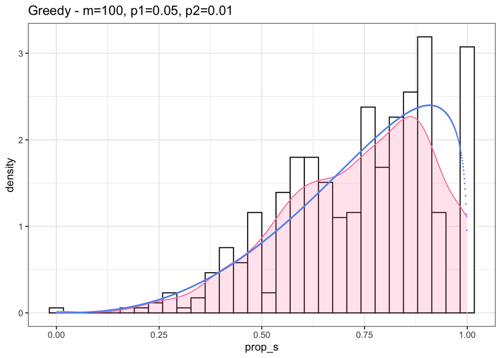

```r
g <- visual(dataset, alpha_star, beta_star)
g + labs(title = "Greedy - m=100, p1=0.05, p2=0.01")
```

### Greedy - group 23 (m=100, pa=0.5, p1=0.1, p2=0.01, pr=2)

#### warning: there are inf values in this situation

```r
# Greedy m=100, pa=0.5, p1=0.1, p2=0.01, pr=2
dataset <- num_greedy_05_m100_pr2_13[501:1000,]
data <- dataset$prop_s
n <- length(data)
eff_n <- sum(!is.na(data)) # the number of non-na elements
print(paste("The number of non-na elements is",eff_n))
```

```
## [1] "The number of non-na elements is 500"
```

```r
par <- ebeta(data, method = "mle") # the warning may come from the fact that several values = 1
```

```
## Warning in nlminb(start = c(shape1, shape2), objective = fcn, mlx =
## mean(log(x)), : NA/NaN function evaluation
```

```r
# ebeta(data[500:1000], method = "mme")
alpha_star <- as.numeric(par$parameters[1])
beta_star <- as.numeric(par$parameters[2])
print(paste("The mle estimator for alpha = ", alpha_star, "beta =", beta_star))
```

```
## [1] "The mle estimator for alpha =  2.57967871635451 beta = 1.27503915482362"
```

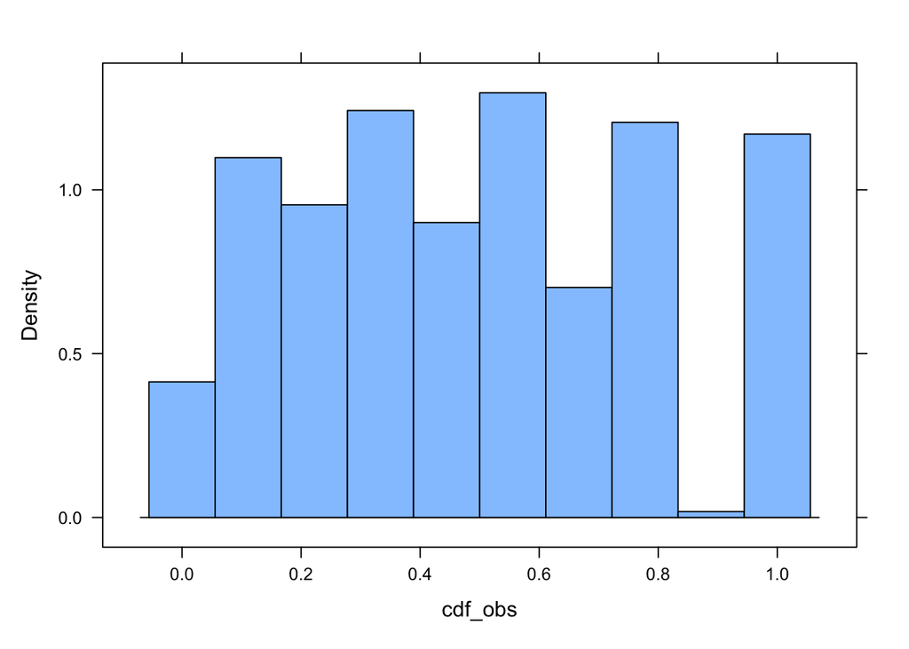

```r
# histogram(alpha_emp)
# histogram(beta_emp)
# mean(alpha_emp)
# alpha_star
# mean(beta_emp)
# beta_star

cdf_obs <- numeric(n)
for (i in 1:n){
  s <- data[i]
  cdf_obs[i] <- pbeta(s, shape1 = alpha_star, shape2 = beta_star)
}

histogram(cdf_obs)
```

```r
ddst.uniform.test(cdf_obs, compute.p = TRUE)
```

```
##
##  Data Driven Smooth Test for Uniformity
##
## data:  cdf_obs,   base: ddst.base.legendre   c: 2.4
## WT = 924.82, n. coord = 10, p-value < 2.2e-16
```

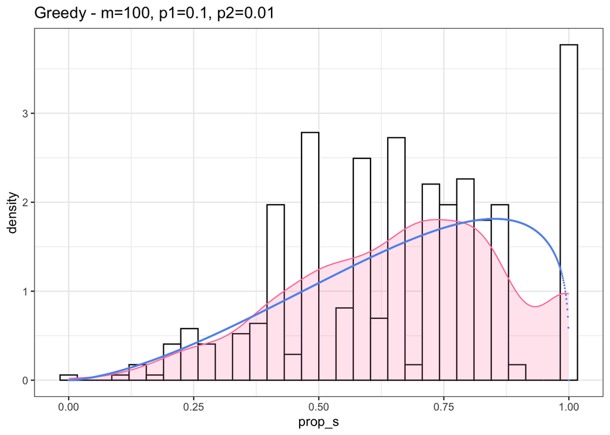

```r
g <- visual(dataset, alpha_star, beta_star)
g + labs(title = "Greedy - m=100, p1=0.1, p2=0.01")
```

### Greedy - group 24 (m=100, pa=0.5, p1=0.8, p2=0.01, pr=2)

#### warning: there are inf values in this situation

```r
# Greedy m=100, pa=0.5, p1=0.8, p2=0.01, pr=2
dataset <- num_greedy_05_m100_pr2_14[501:1000,]
data <- dataset$prop_s
n <- length(data)
eff_n <- sum(!is.na(data)) # the number of non-na elements
print(paste("The number of non-na elements is",eff_n))
```

```
## [1] "The number of non-na elements is 392"
```

```r
par <- ebeta(data, method = "mle") # the warning may come from the fact that several values = 1
```

```
## Warning in is.not.finite.warning(x): There were 243 nonfinite values in x : 108
## NA's, 135 +-Inf's
```

```r
# ebeta(data[500:1000], method = "mme")
alpha_star <- as.numeric(par$parameters[1])
beta_star <- as.numeric(par$parameters[2])
print(paste("The mle estimator for alpha = ", alpha_star, "beta =", beta_star))
```

```
## [1] "The mle estimator for alpha =  0.0880771522624907 beta = 0.0995125836854079"
```

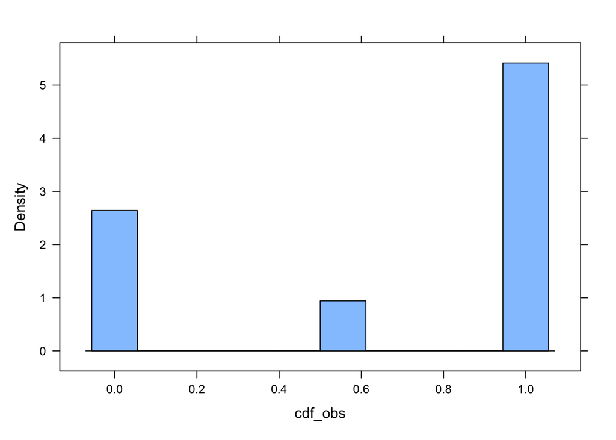

```r
# histogram(alpha_emp)
# histogram(beta_emp)
# mean(alpha_emp)
# alpha_star
# mean(beta_emp)
# beta_star

cdf_obs <- numeric(n)
for (i in 1:n){
  s <- data[i]
  cdf_obs[i] <- (pbeta(s, shape1 = alpha_star, shape2 = beta_star))
}

histogram(cdf_obs)
```

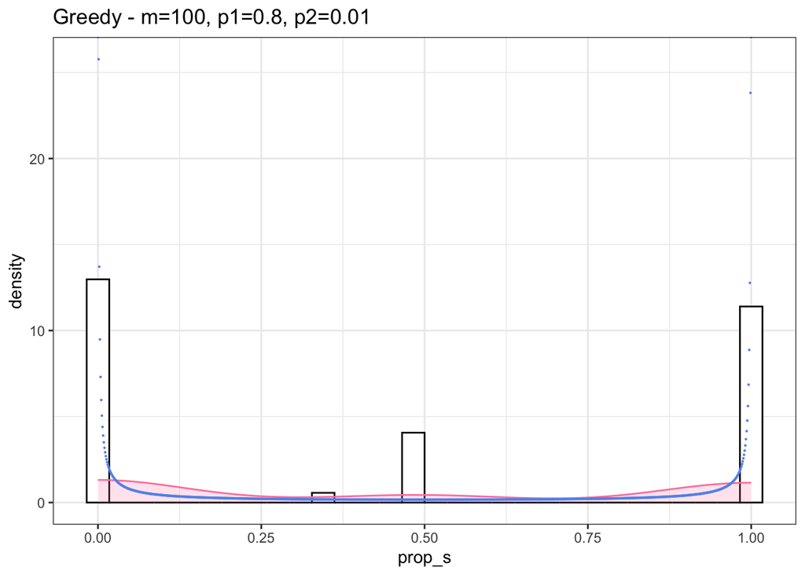

```r
# ddst.uniform.test(cdf_obs, compute.p = TRUE)

g <- visual(dataset, alpha_star, beta_star)
g + labs(title = "Greedy - m=100, p1=0.8, p2=0.01")
```